# Data Dive - Confidence Intervals

Amritha Prakash

2023-09-29

## ASSIGNMENT 6

### Task(s)

- Part 1: Build at least three sets of variable combinations
  - For each set of variables, include at least one column that you created (i.e., calculated based on others)
  - All variables for this data dive should be either continuous (i.e., numeric) or ordered (e.g., [‘small’, ‘medium’, ‘large’] is okay, but [“apples”, “oranges”, “bananas”] is not)
  - For each set, there should be one response variable with the others as explanatory variables
- Part 2: Plot a visualization for each response-explanatory relationship, and draw some conclusions based on the plot
  - Use what we’ve covered so far in class to scrutinize the plot (e.g., are there any outliers?)
- Part 3: Calculate the appropriate correlation coefficient for each of these combinations
  - Explain why the value makes sense (or doesn’t) based on the visualization(s)
- Part 4: Build a confidence interval for each of the response variables. Provide a detailed conclusion of the response variable (i.e., the population) based on your confidence interval.

### **Read the Data**

```r
Superstore_data=read.csv("SampleSuperstore_final.csv")
head(Superstore_data)
```

```
##        Ship.Mode   Segment       Country            City      State Postal.Code
## 1   Second Class  Consumer United States       Henderson   Kentucky       42420
## 2   Second Class  Consumer United States       Henderson   Kentucky       42420
## 3   Second Class Corporate United States     Los Angeles California       90036
## 4 Standard Class  Consumer United States Fort Lauderdale    Florida       33311
## 5 Standard Class  Consumer United States Fort Lauderdale    Florida       33311
## 6 Standard Class  Consumer United States     Los Angeles California       90032
##   Region        Category Sub.Category    Sales Quantity Discount    Profit
## 1  South       Furniture    Bookcases 261.9600        2     0.00   41.9136
## 2  South       Furniture       Chairs 731.9400        3     0.00  219.5820
## 3   West Office Supplies       Labels  14.6200        2     0.00    6.8714
## 4  South       Furniture       Tables 957.5775        5     0.45 -383.0310
## 5  South Office Supplies      Storage  22.3680        2     0.20    2.5164
## 6   West       Furniture  Furnishings  48.8600        7     0.00   14.1694
```

## **1. Set 1: -** Predicting Profit

- Build at least three sets of variable combinations
  - Response Variable: Profit
  - Explanatory Variables: Sales, Quantity, Discount
  - Set 1

```r
superstore_set_1 <- Superstore_data |>
  select(Sales, Quantity, Discount, Profit)
head(superstore_set_1)
```

```
##      Sales Quantity Discount    Profit
## 1 261.9600        2     0.00   41.9136
## 2 731.9400        3     0.00  219.5820
## 3  14.6200        2     0.00    6.8714
## 4 957.5775        5     0.45 -383.0310
## 5  22.3680        2     0.20    2.5164
## 6  48.8600        7     0.00   14.1694
```

- In the above set, will try to find a relation between each explanatory variable i.e. sales, quantity and discount with Profit.
- Within set1, Visualization for each response-explanatory relationship. Further calculation of Correlation and identifying the confidence Interval:
  1. PROFIT VS SALES -
  - Create a scatterplot for Profit vs. Sales

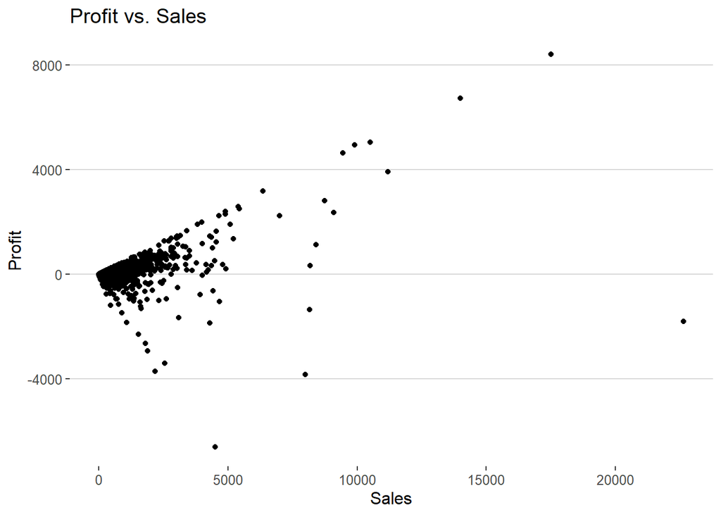

  ```r
  ggplot(data = superstore_set_1, aes(x = Sales, y = Profit))+
  geom_point() +
  labs(x = "Sales", y = "Profit") +
  ggtitle("Profit vs. Sales") +
    theme_hc()
  ```

  - Not a clear linear relation between Profit and sales. But can see for most it follows the linear trend, i.e. as the sale prices increase the profit also increases.
  - Calculate the appropriate correlation coefficient between two variables,i.e. between Profit and Sales

  ```r
  correlation_coefficient <- round(cor(superstore_set_1$Profit, superstore_set_1$Sales),2)

  # Print the correlation coefficient
  print(correlation_coefficient)
  ```

  ```
  ## [1] 0.48
  ```

  - Positive value of Correlation indicates that there is somewhat linear relationship between Profit and Sales.
  - So can say that the visualization and Correlation speak the same that there is somewhat linear correlation between Profit and Sales.
  2. PROFIT VS QUANTITY -
  - Create a scatterplot for Profit vs. Quantity

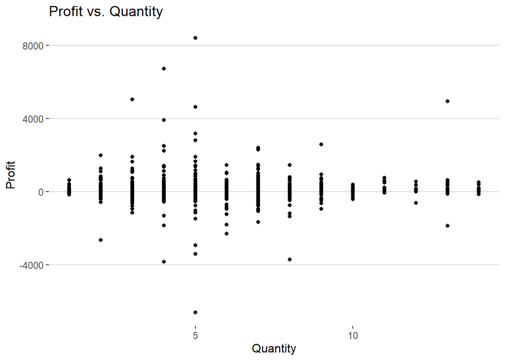

  ```r
  ggplot(data = superstore_set_1, aes(x = Quantity, y = Profit))+
  geom_point() +
  labs(x = "Quantity", y = "Profit") +
  ggtitle("Profit vs. Quantity") +
    theme_hc()
  ```

  - Not a clear relation between Profit and Quantity. All points are scattered all over.
  - Calculate the appropriate correlation coefficient between two variables,i.e. between Profit and Quantity

  ```r
  correlation_coefficient <- round(cor(superstore_set_1$Profit, superstore_set_1$Quantity),2)

  # Print the correlation coefficient
  print(correlation_coefficient)
  ```

  ```
  ## [1] 0.07
  ```

  - Here correlation between Profit and quantity is near zero,i.e. points are randomly scattered.
  - So can say that the visualization and Correlation speak the same that there is somewhat no particular relation which can be predicted from Profit and quantity.
  3. PROFIT VS DISCOUNT -
  - Create a scatterplot for Profit vs. discount

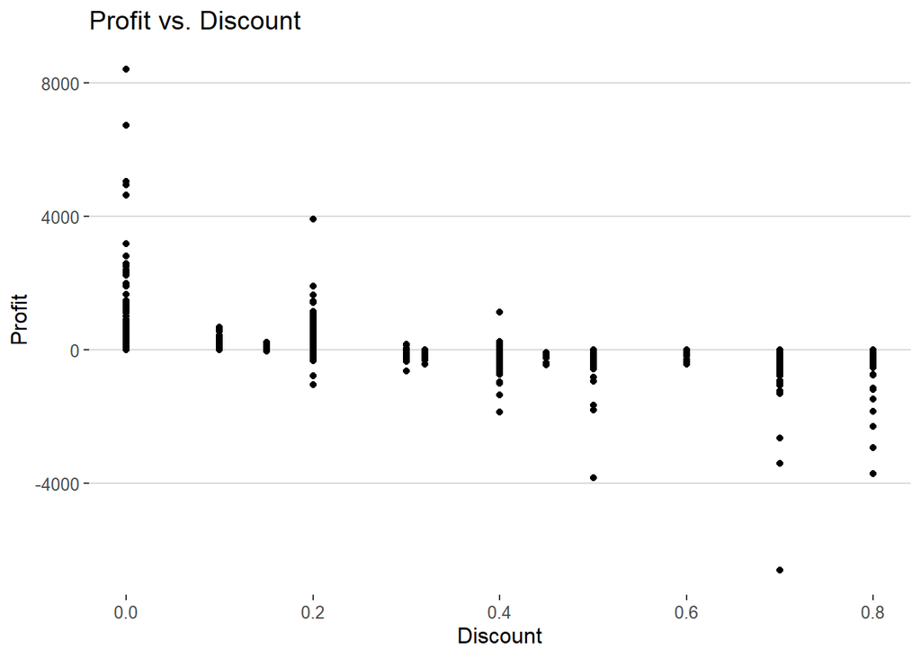

  ```r
  ggplot(data = superstore_set_1, aes(x = Discount, y = Profit))+
  geom_point() +
  labs(x = "Discount", y = "Profit") +
  ggtitle("Profit vs. Discount") +
    theme_hc()
  ```

  - Can see it follows the negative linear trend, i.e. as the discount increases the profit descreases
  - Calculate the appropriate correlation coefficient between two variables,i.e. between Profit and Discount

  ```r
  correlation_coefficient <- round(cor(superstore_set_1$Profit, superstore_set_1$Discount),2)

  # Print the correlation coefficient
  print(correlation_coefficient)
  ```

  ```
  ## [1] -0.22
  ```

Assuming, If we want to calculate a 95% confidence interval for the “Profit” variable:

```r
print(paste("Min of Profit",min(superstore_set_1$Profit)))
```

```
## [1] "Min of Profit -6599.978"
```

```r
print(paste("Max of Profit",max(superstore_set_1$Profit)))
```

```
## [1] "Max of Profit 8399.976"
```

```r
# Calculate the sample mean and standard error of the mean for the Profit variable
profit_mean <- mean(superstore_set_1$Profit)
profit_se <- sd(superstore_set_1$Profit)/sqrt(length(superstore_set_1$Profit))

# Calculate the t-critical value for the 95% confidence interval with 10 degrees of freedom
t_critical <- qt(0.975, df = 10)

# Calculate the margin of error
margin_of_error <- t_critical * profit_se

# Construct the 95% confidence interval for the Profit variable
profit_ci_upper <- profit_mean + margin_of_error
profit_ci_lower <- profit_mean - margin_of_error

print(paste("Confidence level of Profit: ",profit_ci_lower," to ",profit_ci_upper))
```

```
## [1] "Confidence level of Profit:  23.4356892364713  to  33.878103379098"
```

- Also, we know the Profit min and max to be -6599.978 and 8399.976 respectively
- From above can figure out that the Confidence Inetrval for Profit to be between the range 23.4356892364713 to 33.878103379098.
- This states that 95 out of 100 times the true population mean would exist within the Confidence Interval of 23.4356892364713 to 33.878103379098.

## **2. Set 2: -** Predicting Sales

- Build at least three sets of variable combinations
  - Response Variable: Sales
  - Explanatory Variables: Quantity, Discount, Category (convert to numeric, e.g., Furniture: 1, Office Supplies:2)

```r
#Region Category to numbers
unique(Superstore_data$Category)
```

```
## [1] "Furniture"       "Office Supplies" "Technology"
```

```r
# Create a new column for region_numeric
Superstore_data <- Superstore_data %>%
  mutate(Category_numeric = recode(Category, "Furniture" = 1, "Office Supplies" = 2, "Technology" = 3))


Superstore_data |> select(Category,Category_numeric) |> head()
```

```
##          Category Category_numeric
## 1       Furniture                1
## 2       Furniture                1
## 3 Office Supplies                2
## 4       Furniture                1
## 5 Office Supplies                2
## 6       Furniture                1
```

- Set2

```r
superstore_set_2 <- Superstore_data |>
  select(Quantity,Discount,Category,Category_numeric, Sales)
head(superstore_set_2)
```

```
##   Quantity Discount        Category Category_numeric    Sales
## 1        2     0.00       Furniture                1 261.9600
## 2        3     0.00       Furniture                1 731.9400
## 3        2     0.00 Office Supplies                2  14.6200
## 4        5     0.45       Furniture                1 957.5775
## 5        2     0.20 Office Supplies                2  22.3680
## 6        7     0.00       Furniture                1  48.8600
```

In this above set, will try to predict the sales (response variable) based on quantity, discount, and category.

- Within set2, Visualization for each response-explanatory relationship. Further calculation of Correlation and identifying the confidence Interval:
  1. SALES VS QUANTITY -
  - Create a scatterplot for Sales vs. Quantity

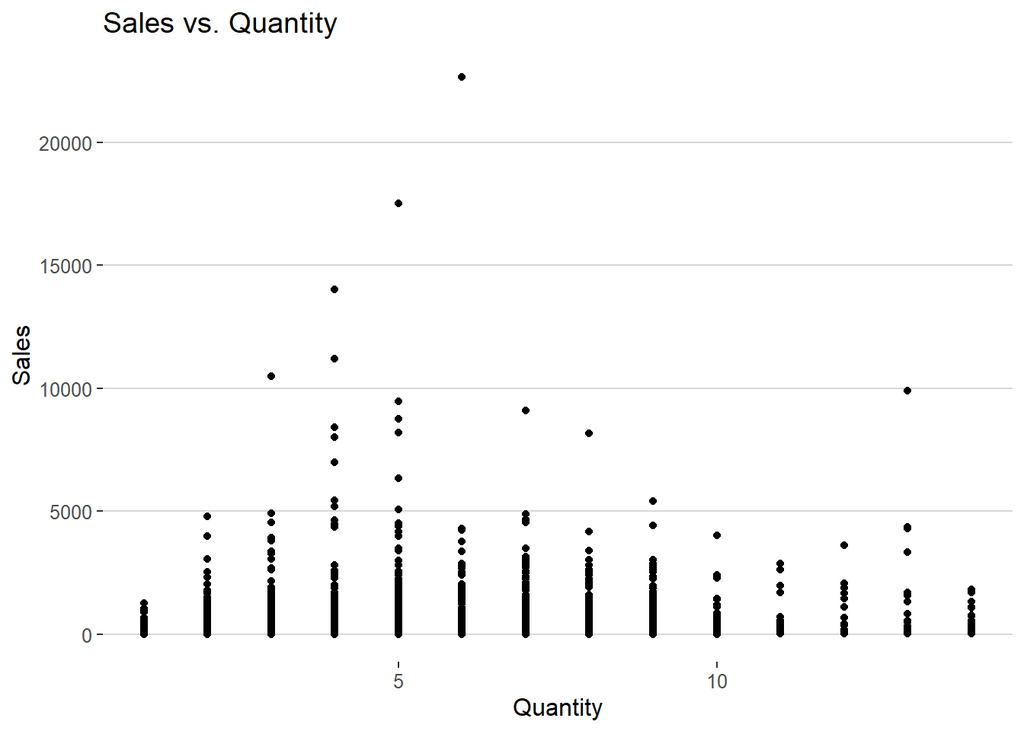

  ```r
  ggplot(data = superstore_set_2, aes(x = Quantity, y = Sales))+
  geom_point() +
  labs(x = "Quantity", y = "Sales") +
  ggtitle("Sales vs. Quantity") +
    theme_hc()
  ```

  - Not a clear relation between Sales and Quantity. All points are scattered over the region where sale is less, while quantity vary in there.
  - Calculate the appropriate correlation coefficient between two variables,i.e. between Quantity and Sales

  ```r
  correlation_coefficient <- round(cor(superstore_set_2$Quantity, superstore_set_2$Sales),2)

  # Print the correlation coefficient
  print(correlation_coefficient)
  ```

  ```
  ## [1] 0.2
  ```

  - Positive value of Correlation indicates that there is somewhat linear relationship between Quantity and Sales. But since the value is nearby 0 i.e. it is 0.2. I would say that not much can be said. There is not much strength in the relationship between Sales and Quantity
  - So conclusively, can say that the visualization and Correlation speak the same that there is not much which can be figured between the parameters - Quantity and sales.
  2. SALES VS DISCOUNT -
  - Create a scatterplot for Sales vs. Discount.

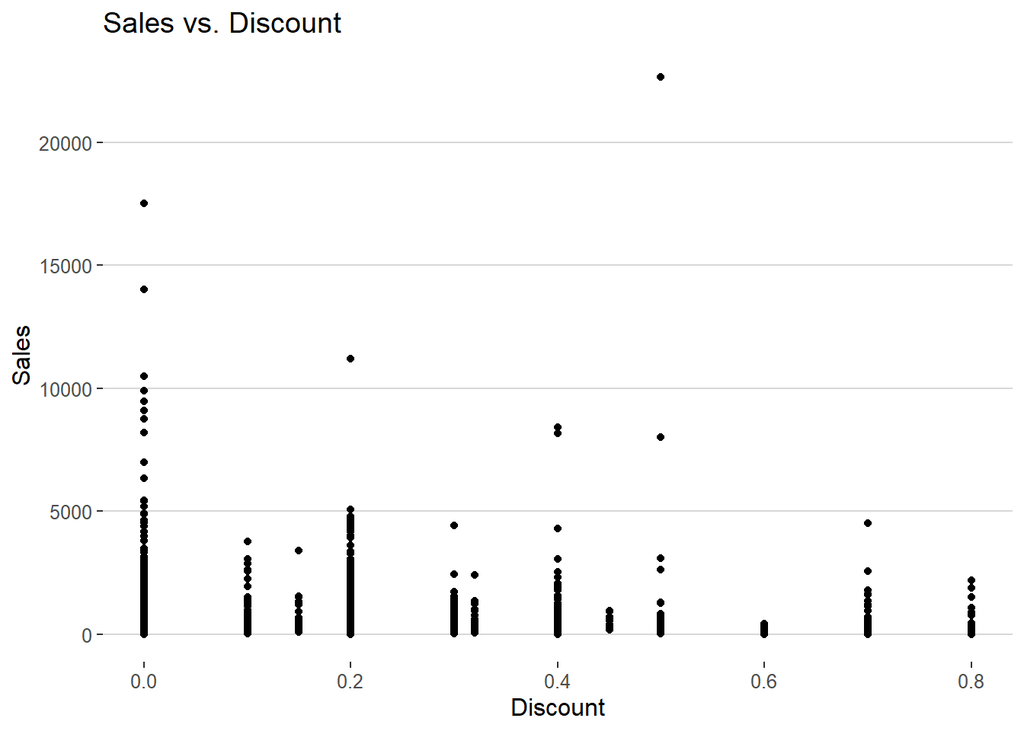

  ```r
  ggplot(data = superstore_set_2, aes(x = Discount, y = Sales))+
  geom_point() +
  labs(x = "Discount", y = "Sales") +
  ggtitle("Sales vs. Discount") +
    theme_hc()
  ```

  - Not a clear relation between Sales and Discount. All points are somewhat scattered over the region but if we closely look as the discount increases the sale decreases.
  - Calculate the appropriate correlation coefficient between two variables,i.e. between Discount and Sales

  ```r
  correlation_coefficient <- round(cor(superstore_set_2$Discount, superstore_set_2$Sales),2)

  # Print the correlation coefficient
  print(correlation_coefficient)
  ```

  ```
  ## [1] -0.03
  ```

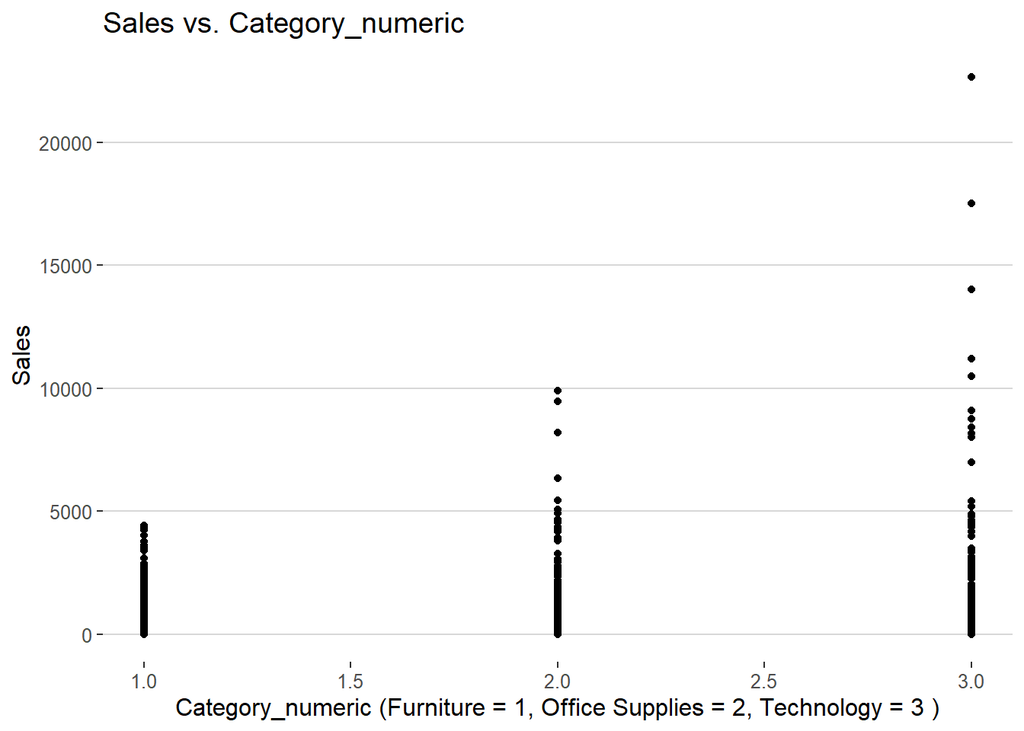

  ```r
  ggplot(data = superstore_set_2, aes(x = Category_numeric, y = Sales))+
  geom_point() +
  labs(x = "Category_numeric (Furniture = 1, Office Supplies = 2, Technology = 3 )", y = "Sales") +
  ggtitle("Sales vs. Category_numeric") +
    theme_hc()
  ```

Here 1,2 and 3 in category_numeric indicate the following categories - “Furniture” = 1, “Office Supplies” = 2, “Technology” = 3

```r
correlation_coefficient <- round(cor(superstore_set_2$Category_numeric, superstore_set_2$Sales),2)

# Print the correlation coefficient
print(correlation_coefficient)
```

```
## [1] 0.04
```

- Positive value of Correlation indicates that there is slight relation between the parameters. But since the value is small positive value which is nearby 0 i.e. it is 0.04. I would say that not much can be said. There is not much strength in the relationship between Sales and Category. Majorly, can say that it is not giving much information.
- So conclusively, can say that the visualization and Correlation speak the same that there is not much which can be figured between the parameters - Category and sales. Maybe can state that with respect to certain category of products the sales may go up but not much can be figured out with such a correlation value.

Assuming, If we want to calculate a 95% confidence interval for the “Sales” variable:

```r
print(paste("Min of Sales",min(superstore_set_2$Sales)))
```

```
## [1] "Min of Sales 0.444"
```

```r
print(paste("Max of Sales",max(superstore_set_2$Sales)))
```

```
## [1] "Max of Sales 22638.48"
```

```r
# Calculate the sample mean and standard error of the mean for the Profit variable
sales_mean <- mean(superstore_set_2$Sales)
sales_se <- sd(superstore_set_2$Sales)/sqrt(length(superstore_set_2$Sales))

# Calculate the t-critical value for the 95% confidence interval with 10 degrees of freedom
t_critical <- qt(0.975, df = 10)

# Calculate the margin of error
margin_of_error <- t_critical * sales_se

# Construct the 95% confidence interval for the Profit variable
sales_ci_upper <- sales_mean + margin_of_error
sales_ci_lower <- sales_mean - margin_of_error

print(paste("Confidence level of Sales: ",sales_ci_lower," to ",sales_ci_upper))
```

```
## [1] "Confidence level of Sales:  215.967066697444  to  243.748934963553"
```

## **3. Set 3: -** Predicting Discount at which products are sold

- Build at least three sets of variable combinations
  - Response Variable: Discount
  - Explanatory Variables: Quantity, Region (by converting to numeric), Ship Mode (convert to numeric representation)

```r
#Region convert to numbers for correlation  purpose
unique(Superstore_data$Region)
```

```
## [1] "South"   "West"    "Central" "East"
```

```r
# Create a new column for region_numeric
Superstore_data <- Superstore_data %>%
  mutate(Region_numeric = recode(Region, "South" = 1, "West" = 2, "East" = 3, "Central" = 4))


Superstore_data |> select(Region,Region_numeric) |> head()
```

```
##   Region Region_numeric
## 1  South              1
## 2  South              1
## 3   West              2
## 4  South              1
## 5  South              1
## 6   West              2
```

```r
# ShipMode convert to numbers for correlation  purpose
unique(Superstore_data$Ship.Mode)
```

```
## [1] "Second Class"   "Standard Class" "First Class"    "Same Day"
```

```r
Superstore_data <- Superstore_data %>%
  mutate(ShipMode_numeric = recode(Ship.Mode, "Same Day"= 1, "First Class" = 2, "Second Class" = 3, "Standard Class" = 4))


Superstore_data |> select(Ship.Mode,ShipMode_numeric) |> head()
```

```
##        Ship.Mode ShipMode_numeric
## 1   Second Class                3
## 2   Second Class                3
## 3   Second Class                3
## 4 Standard Class                4
## 5 Standard Class                4
## 6 Standard Class                4
```

- Set3

```r
superstore_set_3 <- Superstore_data |>
  select(Quantity,Region,Region_numeric,Ship.Mode,ShipMode_numeric,Discount)
head(superstore_set_3)
```

```
##   Quantity Region Region_numeric      Ship.Mode ShipMode_numeric Discount
## 1        2  South              1   Second Class                3     0.00
## 2        3  South              1   Second Class                3     0.00
## 3        2   West              2   Second Class                3     0.00
## 4        5  South              1 Standard Class                4     0.45
## 5        2  South              1 Standard Class                4     0.20
## 6        7   West              2 Standard Class                4     0.00
```

- Within set3, Visualization for each response-explanatory relationship. Further calculation of Correlation and identifying the confidence Interval:
  1. DISCOUNT VS QUANTITY -
  - Create a scatterplot for Discount vs. Quantity

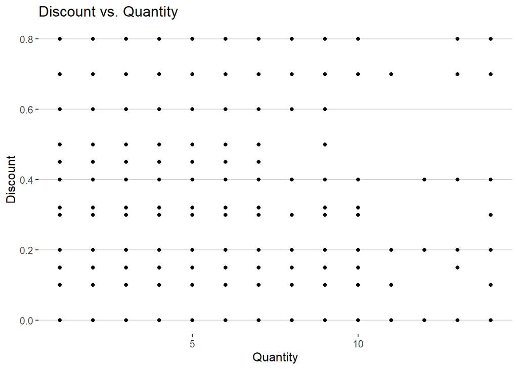

  ```r
  ggplot(data = superstore_set_3, aes(x = Quantity, y = Discount))+
  geom_point() +
  labs(x = "Quantity", y = "Discount") +
  ggtitle("Discount vs. Quantity") +
    theme_hc()
  ```

  - Not a clear relation between Discount and Quantity. All points are scattered over the plot.
  - Calculate the appropriate correlation coefficient between two variables,i.e. between Quantity and Discount

  ```r
    correlation_coefficient <- round(cor(superstore_set_3$Quantity, superstore_set_3$Discount),2)

  # Print the correlation coefficient
  print(correlation_coefficient)
  ```

  ```
  ## [1] 0.01
  ```

  - Positive value of Correlation indicates that there is somewhat linear relationship between Quantity and Discount. But since the value is nearby 0 i.e. it is 0.01. I would say that not much can be said. There is not much strength in the relationship between Discount and Quantity. Or even there is no corelation between those 2 parameters
  - So conclusively, can say that the visualization and Correlation speak the same that there is not much which can be figured between the parameters - Quantity and Discount.
  2. DISCOUNT VS REGION -
  - Create a scatterplot for Region vs. Discount.

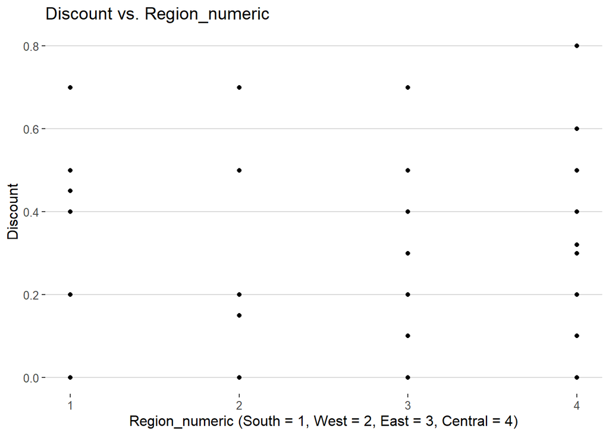

  ```r
  ggplot(data = superstore_set_3, aes(x =Region_numeric , y = Discount))+
  geom_point() +
  labs(x = "Region_numeric (South = 1, West = 2, East = 3, Central = 4)", y = "Discount") +
  ggtitle("Discount vs. Region_numeric ") +
    theme_hc()
  ```

  - Not a clear relation between Region and Discount. All points are somewhat scattered over the region.
  - Calculate the appropriate correlation coefficient between two variables,i.e. between Discount and Region

  ```r
  correlation_coefficient <- round(cor(superstore_set_3$Discount, superstore_set_3$Region_numeric),2)

  # Print the correlation coefficient
  print(correlation_coefficient)
  ```

  ```
  ## [1] 0.18
  ```

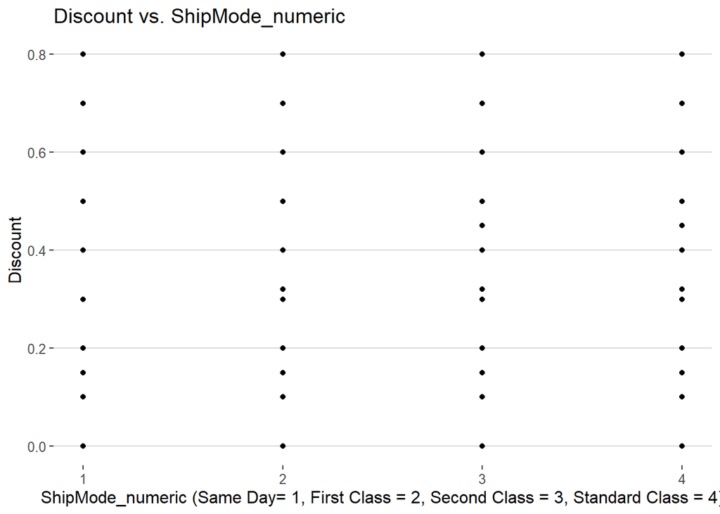

  ```r
  ggplot(data = superstore_set_3, aes(x = ShipMode_numeric, y = Discount))+
  geom_point() +
  labs(x = "ShipMode_numeric (Same Day= 1, First Class = 2, Second Class = 3, Standard Class = 4)", y = "Discount") +
  ggtitle("Discount vs. ShipMode_numeric") +
    theme_hc()
  ```

Here 1,2, 3 and 4 in ShipMode_numeric indicate the following categories -Same Day= 1, First Class = 2, Second Class = 3, Standard Class = 4

- Not a clear relation between ShipMode_numeric and Discount, All points are somewhat scattered over the plot.
- Calculate the appropriate correlation coefficient between two variables,i.e. between ShipMode and Discount.

```r
correlation_coefficient <- round(cor(superstore_set_3$ShipMode_numeric, superstore_set_3$Discount),2)

# Print the correlation coefficient
print(correlation_coefficient)
```

```
## [1] 0.01
```

- Positive value of Correlation indicates that there is slight relation between the parameters. But since the value is small positive value which is nearby 0 i.e. it is 0.01. I would say that not much can be said. There is not much strength in the relationship between Discount and ShipMode. Majorly, can say that it is not giving much information.
- So conclusively, can say that the visualization and Correlation speak the same that there is not much which can be figured between the parameters - Discount and ShipMode.

Assuming, If we want to calculate a 95% confidence interval for the “Discount” variable:

```r
print(paste("Min of Discount",min(superstore_set_3$Discount)))
```

```
## [1] "Min of Discount 0"
```

```r
print(paste("Max of Discount",max(superstore_set_3$Discount)))
```

```
## [1] "Max of Discount 0.8"
```

```r
# Calculate the sample mean and standard error of the mean for the Profit variable
dist_mean <- mean(superstore_set_3$Discount)
dist_se <- sd(superstore_set_3$Discount)/sqrt(length(superstore_set_3$Discount))

# Calculate the t-critical value for the 95% confidence interval with 10 degrees of freedom
t_critical <- qt(0.975, df = 10)

# Calculate the margin of error
margin_of_error <- t_critical * dist_se

# Construct the 95% confidence interval for the Profit variable
Discount_ci_upper <- dist_mean + margin_of_error
Discount_ci_lower <- dist_mean - margin_of_error

print(paste("Confidence level of Sales: ",Discount_ci_lower," to ",Discount_ci_upper))
```

```
## [1] "Confidence level of Sales:  0.151601304494897  to  0.160804138771062"
```

- Also, we know the Discount min and max to be 0 and 0.8 respectively.
- From above can figure out that the Confidence Interval for Discount to be between the range 0.151601304494897 to 0.160804138771062.
- This states that 95 out of 100 times the true population mean for discount would exist within the Confidence Interval of 0.151601304494897 to 0.160804138771062